# SeroMetrics

Summary metrics and application examples are adapted from the following publications:

- Yang B, Lessler J, Zhu H, Jiang CQ, Read JM, Hay JA, Kwok KO, Shen R, Guan Y, Riley S, Cummings DA. [Life course exposures continually shape antibody profiles and risk of seroconversion to influenza](https://journals.plos.org/plospathogens/article?id=10.1371/journal.ppat.1008635). PLoS pathogens. 2020 Jul 23;16(7):e1008635.
- Yang B, Leung NHL, Fox A, Sullivan SG, Ho F, Barr IG, Cheng SMS, Wong SS, Levine MZ, Iuliano AD, Peiris M, Thompson MG, Cowling BJ. Evaluating Antibody Breadth Following Various Enhanced Influenza Vaccines in Older Adults. *In preparation*.

## 2. Data structure

| Variable | Type | Explanation |
| --- | --- | --- |
| *id* | mandatory | This should be the unique id of the sampled participant. |
| *value* | mandatory | This should be the investigated value, usually being titers. |
| *distance* | mandatory | This should be the absolute distance among virus strains, usually being isolation year of the or amino acid (AA) distance between the tested and referenced virus. |
| *strain* | optional | This should be the virus strains. When distance is not provided, one may need to derive isolation year from the information in virus strain. |
| *group* | optional | This should be the group of some sample of a participant. Sometimes, one participant may take tests on the same strains multiple times, and the samples collected from each time forms a sample group. |
| *other variables* | optional | There might be age, sex, and other information regarding the participant. At most times, these variables will not affect the final result of the metrics. |

### 2.1. Simulated data

The following shows a simulated antibody landscape from the following participant:

```r
head(profile, 5)
```

```
## # A tibble: 5 × 5
##      id birth_year sample_year isolation_year log_titer
##   <int>      <int>       <dbl>          <int>     <int>
## 1    25       1985        2020           1980         4
## 2    25       1985        2020           1952         6
## 3    25       1985        2020           1974         4
## 4    25       1985        2020           1975         5
## 5    25       1985        2020           1992         5
```

### 2.2. Transform distance variable

The following shows examples to compute the `distance` variable using different references, which will be further used for metric calculation. In this example, the antibody landscape is arranged by isolation time of the tested virus.

If the antibody landscape is arranged in the antigenic space, the `distance` variable should be computed as the difference in AA substitutions between tested virus and the reference virus. distance_null will be unable to calculate in such situation.

```r
profile = profile %>%
  mutate(
    distance_1 = isolation_year - birth_year, # align to the year of birth
    distance_2 = isolation_year - sample_year, # align to the antiserum collection year
    distance_null = isolation_year # without reference; raw value for isolation year
  )

profile %>%
  select(-id) %>%
  head()
```

```
## # A tibble: 6 × 7
##   birth_year sample_year isolation_year log_titer distance_1 distance_2
##        <int>       <dbl>          <int>     <int>      <int>      <dbl>
## 1       1985        2020           1980         4         -5        -40
## 2       1985        2020           1952         6        -33        -68
## 3       1985        2020           1974         4        -11        -46
## 4       1985        2020           1975         5        -10        -45
## 5       1985        2020           1992         5          7        -28
## 6       1985        2020           2001         7         16        -19
## # ℹ 1 more variable: distance_null <int>
```

## 3. Example of applications

### 3.1. Lessler *et al*. 2012 *PLoS Pathogens*

This is an example using the data set published by [Lessler *et al.*, 2012 *PLoS Pathogens*](https://journals.plos.org/plospathogens/article?id=10.1371/journal.ppat.1002802).

In this data set, cross-sectional antisera were collected, indicating that for each participant, only one titer was available for each tested virus. In this situation, the `group_col` argument can be set to *NULL*, and and since all virus strains have different isolation years, the `mode` argument can be set to *NULL*.

```r
    #show the basic structure of the dataset
    head(lessler,10)
```

```
## # A tibble: 10 × 8
##      age is.vac shift.age titers neut.against         id   loc isolation_year
##    <dbl> <chr>      <dbl>  <dbl> <chr>             <dbl> <dbl>          <dbl>
##  1    75 NA            34      5 1 A/HK/1968(H3N2)     1     1           1968
##  2    35 NA            -6      1 1 A/HK/1968(H3N2)     2     1           1968
##  3    71 1             30      4 1 A/HK/1968(H3N2)     3     1           1968
##  4    65 1             24      3 1 A/HK/1968(H3N2)     4     1           1968
##  5    64 1             23      5 1 A/HK/1968(H3N2)     5     1           1968
##  6    33 5             -8      2 1 A/HK/1968(H3N2)     6     1           1968
##  7    60 1             19      5 1 A/HK/1968(H3N2)     7     1           1968
##  8    43 1              2      5 1 A/HK/1968(H3N2)     8     1           1968
##  9    17 1            -24      1 1 A/HK/1968(H3N2)     9     1           1968
## 10    36 1             -5      1 1 A/HK/1968(H3N2)    10     1           1968
```

#### 3.1.1. Calculate multiple metrics at once

Using `overallData()` function to simultaneously calculate multiple metrics specified in the `required_metrics` argument. The output is a matrix with each individual’s antibody profile, in this case for each participant.

```r
overallResult <- overallData(data = lessler,
                             part_col = "id", # unique id of the participant
                             weight_col = "isolation_year", # specify the column name for weights.
                             val_col = "titers", # specify the column name for the titer value
                             var_trans = 1,
                             gmt_output_trans = 1,
                             required_metrics = c("AUC",
                                                  "ATY",
                                                  "GMT",
                                                  "Prot_prop",
                                                  "Width0",
                                                  "Width2",
                                                  "Width3"), # metrics to be computed
                             col_names = c("auc",
                                           "aty",
                                           "gmt",
                                           "prot_prop",
                                           "Width10",
                                           "Width40",
                                           "Width80") # column names for the calculated metrics in the output matrix

                             )

head(overallResult, 10)
```

```
##    id   auc      aty      gmt  prot_prop Width10   Width40   Width80
## 1   1 143.0 1988.332 3.555556 0.11111111       1 1.0000000 0.8916667
## 2   2 133.5 1986.159 2.777778 0.19444444       1 0.8812500 0.6750000
## 3   3  95.5 1987.741 2.555556 0.12777778       1 0.9083333 0.2166667
## 4   4  59.0 1985.517 1.444444 0.02222222       1 0.1750000 0.0000000
## 5   5 120.5 1985.649 2.777778 0.16666667       1 0.8750000 0.5625000
## 6   6 155.5 1989.786 3.555556 0.35000000       1 0.8000000 0.6833333
## 7   7  66.0 1986.258 1.777778 0.08333333       1 0.3312500 0.0875000
## 8   8 165.0 1988.055 4.222222 0.17777778       1 1.0000000 0.8666667
## 9   9 106.5 1993.411 2.777778 0.23333333       1 0.4750000 0.3458333
## 10 10 165.5 1989.310 4.555556 0.49444444       1 0.9650000 0.6966667
```

#### 3.1.2. Calculate individual metric

You can also calculate a single metric using the corresponding function in the package. This generates a two-column matrix with a unique ID and values for the chosen metric, which can be manually integrated into an overall matrix.

```r
    # average titer year
    atyResult <- atyData(
      data = lessler,
      part_col = c("id"),
      weight_col = c("isolation_year"),
      val_col = c("titers"),
      var_trans = 1
    )

    # area under the curve
    aucResult <- aucData(
      data = lessler,
      part_col = c("id"),
      weight_col = c("isolation_year"),
      val_col = c("titers"),
      var_trans = 1
    )

    # Gini coefficient
    giniResult <- giniData(
      data = lessler,
      part_col = c("id"),
      val_col = c("titers"),
      var_trans = 1
    )

     # Geometric mean titer
    gmtResult <- gmtData(
      data = lessler,
      part_col = c("id"),
      val_col = c("titers"),
      var_trans = 1,
      output_trans = 1
    )

    # Kurtosis
    kurtosisResult <- kurtosisData(
      data = lessler,
      part_col = c("id"),
      weight_col = c("isolation_year"),
      val_col = c("titers"),
      var_trans = 1
    )

    # Maximum titer
    max_titerResult <- max_titerData(
      data = lessler,
      part_col = c("id"),
      val_col = c("titers"),
      var_trans = 1,
      output_trans = 1
    )

    # The proportion of titers above 40
    propResult2 <- propData(
      data = lessler,
      part_col = c("id"),
      val_col = c("titers"),
      var_trans = 1,
      threshold_trans = 1,
      threshold = 2,
      prop_col = "Prop2"
    )

    # The proportion of titers above 80
    propResult3 <-  propData(
      data = lessler,
      part_col = c("id"),
      val_col = c("titers"),
      var_trans = 1,
      threshold_trans = 1,
      threshold = 3,
      prop_col = "Prop3"
    )

    # Using default weight vector
    prot_propResult <- prot_propData(
      data = lessler,
      part_col = c("id"),
      val_col = c("titers")
    )

    # Skewness
    skewnessResult <- skewnessData(
      data = lessler,
      part_col = c("id"),
      weight_col = c("isolation_year"),
      val_col = c("titers"),
      var_trans = 1
    )

     # The width of titers above 40
    widthResult <- widthData(
      data = lessler,
      part_col = c("id"),
      weight_col = c("isolation_year"),
      val_col = c("titers"),
      var_trans = 1,
      threshold_trans = 1,
      threshold = 2,
      width_col = "Width2"
    )

    # Combine calculated metrics
    overallResult <- atyResult %>%
      left_join(aucResult, by = "id") %>%
      left_join(giniResult, by = "id") %>%
      left_join(gmtResult, by = "id") %>%
      left_join(kurtosisResult, by = "id") %>%
      left_join(max_titerResult, by = "id") %>%
      left_join(propResult2, by = "id") %>%
      left_join(propResult3, by = "id") %>%
      left_join(prot_propResult, by = "id") %>%
      left_join(skewnessResult, by = "id") %>%
      left_join(widthResult, by = "id")

    head(overallResult,10)
```

```
##    id      ATY   AUC gini_coefficient      GMT Kurtosis Max_titer     Prop2
## 1   1 1988.332 143.0        0.1640625 3.555556 1.707120         5 1.0000000
## 2   2 1986.159 133.5        0.3300000 2.777778 1.561969         5 0.7777778
## 3   3 1987.741  95.5        0.2391304 2.555556 1.620069         4 0.8888889
## 4   4 1985.517  59.0        0.2500000 1.444444 1.413219         3 0.3333333
## 5   5 1985.649 120.5        0.2700000 2.777778 1.519771         5 0.8888889
## 6   6 1989.786 155.5        0.2656250 3.555556 2.269066         5 0.8888889
## 7   7 1986.258  66.0        0.3437500 1.777778 1.306238         5 0.4444444
## 8   8 1988.055 165.0        0.1184211 4.222222 1.598491         5 1.0000000
## 9   9 1993.411 106.5        0.4000000 2.777778 4.401814         6 0.6666667
## 10 10 1989.310 165.5        0.2621951 4.555556 1.817756         7 0.8888889
##        Prop3  Prot_prop     Skewness    Width2
## 1  0.8888889 0.11111111 -0.416613804 1.0000000
## 2  0.4444444 0.19444444  0.069766047 0.8812500
## 3  0.3333333 0.12777778 -0.476035601 0.9083333
## 4  0.1111111 0.02222222 -0.007246871 0.1750000
## 5  0.4444444 0.16666667  0.040338839 0.8750000
## 6  0.5555556 0.35000000 -0.655390135 0.8000000
## 7  0.1111111 0.08333333 -0.139036401 0.3312500
## 8  0.8888889 0.17777778 -0.407332564 1.0000000
## 9  0.3333333 0.23333333 -1.435641127 0.4750000
## 10 0.7777778 0.49444444 -0.675249938 0.9650000
```

#### 3.1.3. Profile Plotting

##### 3.1.3.1. Individual Profile

Use the function `individualPlot()` to plot an individual profile.

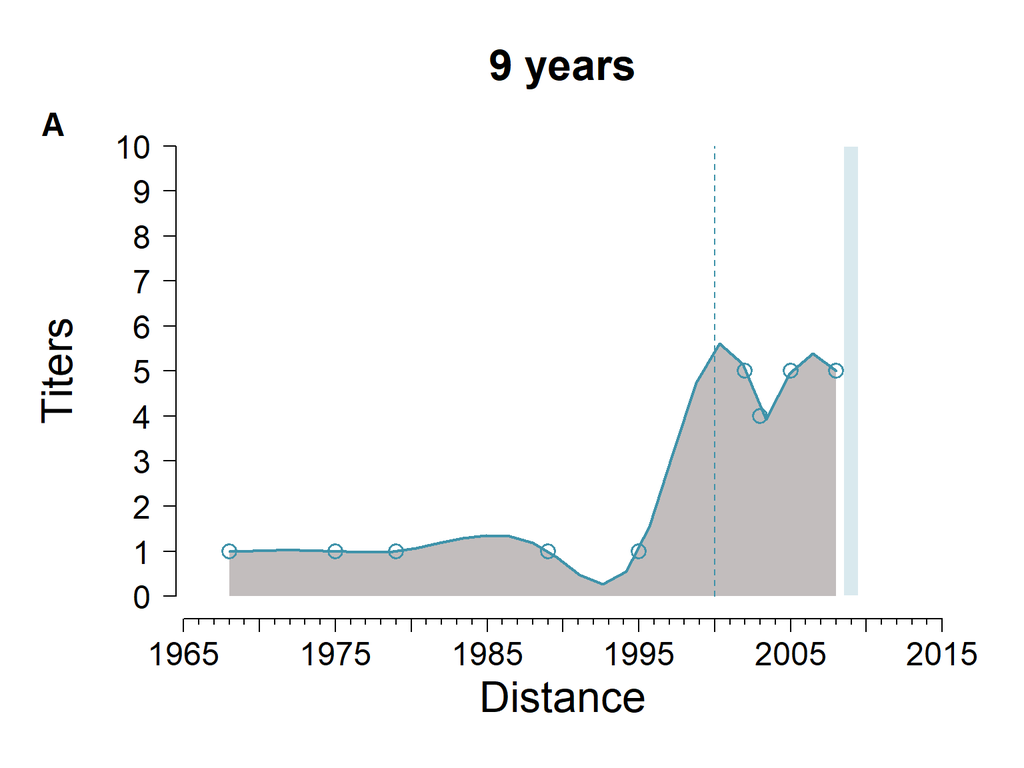

```r
# add the column indicating participants' birth year
lessler$year_of_birth <- lessler$isolation_year - lessler$shift.age

ids = c(143) # Plot the individual profile whose id is 143.

sapply(1:length(ids), function(i) {

  individualPlot(i = i,
                 ids = ids,
                 df = lessler,
                 part_col = "id",
                 weight_col = "isolation_year",
                 val_col = "titers",
                 age_col = "age",
                 birth_col = "year_of_birth",
                 sample_years = 2009,
                 x.min = 1965,
                 x.max = 2015,
                 x.diff.1 = 5,
                 x.diff.2 = 1,
                 y.min = 0,
                 y.max = 10,
                 legends = LETTERS[1])

})
```

You can also plot multiple individual profiles.

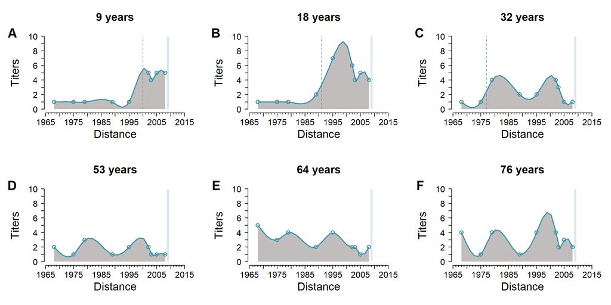

```r
ids <- c(143,64,118,34,5,125)  # Plot the profile of the id 143, 64, 118, 34, 5, 125.
sample_years <- rep(2009,6)

mat <- rbind(matrix(1:6,
                    nrow = 2, ncol = 3,
                    byrow = TRUE))

layout(mat,
       widths = rep(1.5, 3),
       heights = rep(1.0, 2))

sapply(1:length(ids), function(i) {

  individualPlot(i = i,
                 ids = ids,
                 df = lessler,
                 part_col = "id",
                 weight_col = "isolation_year",
                 val_col = "titers",
                 age_col = "age",
                 birth_col = "year_of_birth",
                 sample_years = sample_years,
                 x.min = 1965,
                 x.max = 2015,
                 x.diff.1 = 5,
                 x.diff.2 = 1,
                 y.min = 0,
                 y.max = 10,
                 legends = LETTERS[1:6])

})
```

##### 3.1.3.2. Profile Comparison

Use the function `dualPlot()` to plot the comparison between a pair of profiles.

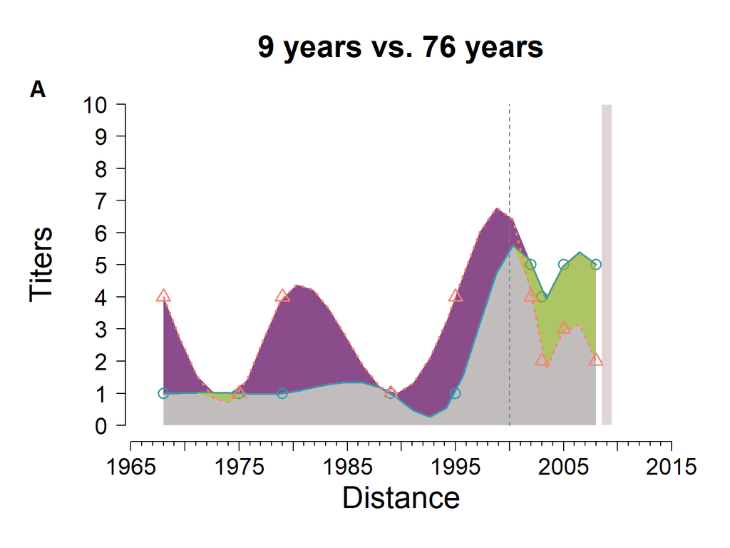

```r
ids.1 = c(143)
ids.2 = c(125) # The comparison pair of ids is (143, 125)

sapply(1:length(ids.1), function(i) {

  dualPlot(i = i,
           ids.1 = ids.1,
           ids.2 = ids.2,
           df = lessler,
           part_col = "id",
           weight_col = "isolation_year",
           val_col = "titers",
           age_col = "age",
           birth_col = "year_of_birth",
           sample_years.1 = 2009,
           sample_years.2 = 2009,
           x.min = 1965,
           x.max = 2015,
           x.diff.1 = 5,
           x.diff.2 = 1,
           y.min = 0,
           y.max = 10,
           legends = LETTERS[1])

})
```

You can also plot comparisons between multiple pairs of profiles.

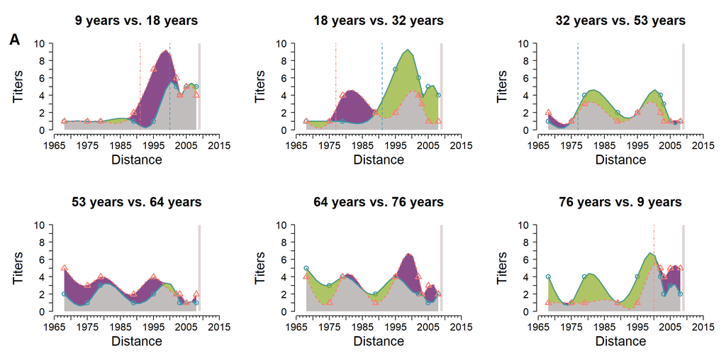

```r
ids.1 = c(143,64,118,34,5,125)
ids.2 = c(64,118,34,5,125,143) # The comparison pairs of ids are (143,64), (64,118), (118,34), (34,5), (5,125), (125,143).

mat <- rbind(matrix(1:6,
                    nrow = 2, ncol = 3,
                    byrow = TRUE))

layout(mat,
       widths = rep(1.5, 3),
       heights = rep(1.0, 2))

sapply(1:length(ids.1), function(i) {

  dualPlot(i = i,
           ids.1 = ids.1,
           ids.2 = ids.2,
           df = lessler,
           part_col = "id",
           weight_col = "isolation_year",
           val_col = "titers",
           age_col = "age",
           birth_col = "year_of_birth",
           sample_years.1 = rep(2009, 6),
           sample_years.2 = rep(2009, 6),
           x.min = 1965,
           x.max = 2015,
           x.diff.1 = 5,
           x.diff.2 = 1,
           y.min = 0,
           y.max = 10,
           legends = LETTERS[1])

})
```

##### 3.1.3.3. Conceptual Plot

Use the function `conceptualPlotAUC()`, `conceptualPlotWidth()`, `conceptualPlotATY()` to plot the conceptual plots of a profile, giving insights into the profile regarding AUC, Width, and ATY.

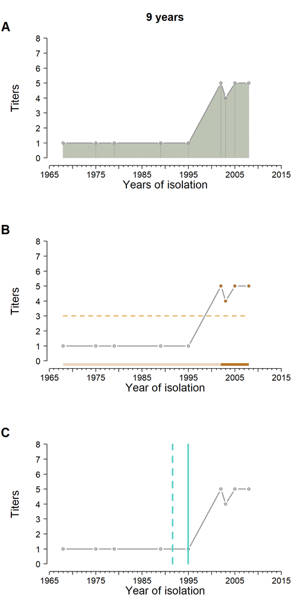

```r
ids <- c(143) # Plot the profile whose id is 143

mat <- rbind(matrix(1:3,
                    nrow = 3, ncol = 1,
                    byrow = FALSE))

layout(mat,
       widths = 1.5,
       heights = c(1.0, 1.0, 1.0))

sapply(1:length(ids), function(i) {

  # auc
  conceptualPlotAUC(i = i,
                    ids = ids,
                    df = lessler,
                    part_col = "id",
                    weight_col = "isolation_year",
                    val_col = "titers",
                    age_col = "age",
                    var_trans = 1,
                    legends = LETTERS[1])

  # width 1:40
  conceptualPlotWidth(i = i,
                      ids = ids,
                      df = lessler,
                      part_col = "id",
                      weight_col = "isolation_year",
                      val_col = "titers",
                      var_trans = 1,
                      legends = LETTERS[2])

  # aty
  conceptualPlotATY(i = i,
                    ids = ids,
                    df = lessler,
                    part_col = "id",
                    weight_col = "isolation_year",
                    val_col = "titers",
                    var_trans = 1,
                    legends = LETTERS[3])

})
```

You can plot conceptual plots of multiple profiles as well.

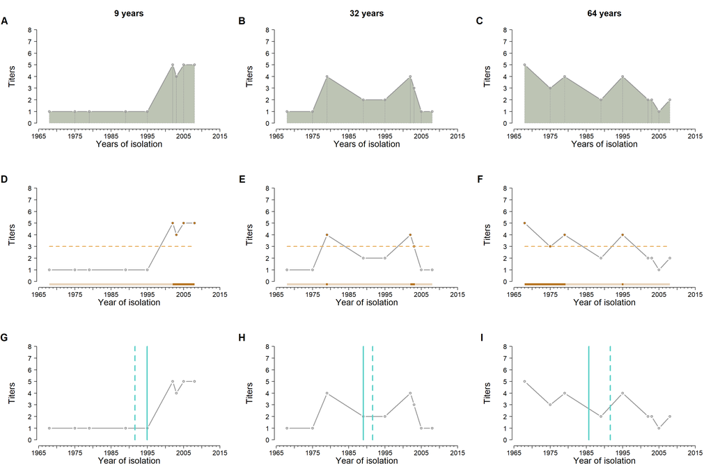

```r
ids <- c(143,118,5) # Plot the profiles whose id are 143, 118, 5.

mat <- rbind(matrix(1:9,
                    nrow = 3, ncol = 3,
                    byrow = FALSE))

layout(mat,
       widths = rep(1.5, 3),
       heights = c(1.0, 1.0, 1.0))

sapply(1:length(ids), function(i) {

  # auc
  conceptualPlotAUC(i = i,
                    ids = ids,
                    df = lessler,
                    part_col = "id",
                    weight_col = "isolation_year",
                    val_col = "titers",
                    age_col = "age",
                    var_trans = 1,
                    legends = LETTERS[1:3])

  # width 1:40
  conceptualPlotWidth(i = i,
                      ids = ids,
                      df = lessler,
                      part_col = "id",
                      weight_col = "isolation_year",
                      val_col = "titers",
                      var_trans = 1,
                      legends = LETTERS[4:6])

  # aty
  conceptualPlotATY(i = i,
                    ids = ids,
                    df = lessler,
                    part_col = "id",
                    weight_col = "isolation_year",
                    val_col = "titers",
                    var_trans = 1,
                    legends = LETTERS[7:9])

})
```

### 3.2. Fonville *et al*. 2014 *Science*

This is an example using the data set published by [*Fonville* et al., 2014 *Science*](https://www.science.org/doi/10.1126/science.1256427).

In this dataset, longitudinal antisera were collected from the same population over six years. For each participant, multiple titer values are available for each tested virus, corresponding to antiserum collected during each visit.

In this case, the `group_col` is the sample year, and different viruses share the same `isolation_year`, making the `mode` necessary.

Additionally, the raw data has a specific structure where each tested virus forms one column. Therefore, data transformation (from a wide table to a long table) should be done first.

#### 3.2.0. Data Transformation

```r
    # data transformation
    transformed_df <- dataTransform(df = fonville, panel = 1, col_start = 7, col_end = ncol(fonville))

    transformed_df <- transformed_df %>%
  mutate(strain = case_when(
    str_detect(strain, "/02$") ~ str_replace(strain, "/02$", "/2002"),
    TRUE ~ strain))%>%
  mutate(titer = case_when(
    str_detect(titer, "\\*") ~ str_replace(titer, "\\*", "10"),
    TRUE ~ titer))%>%
  mutate(titer = case_when(
    str_detect(titer, "<10") ~ str_replace(titer, "<10", "5"),
    TRUE ~ titer))%>%
  mutate(titer = case_when(
    str_detect(titer, ">=1280") ~ str_replace(titer, ">=1280", "9"),
    TRUE ~ titer))%>%
  mutate(titer = as.numeric(titer)) %>%
  mutate(
    isolation_year = case_when(
      str_detect(str_sub(strain, -4), "^\\d{4}$") ~ as.numeric(str_sub(strain, -4)),
      TRUE ~ as.numeric(str_sub(strain, -2)) + 1900
    )
  )
    # show the basic structure of the dataset
    head(transformed_df,10)
```

```
## # A tibble: 10 × 9
##    `Subject Number` `Sample Year` `Year of Birth` Sample  `PCR Results`
##               <dbl>         <dbl>           <dbl> <chr>   <chr>
##  1                1          2007            1957 H3 PCR+ <NA>
##  2                1          2007            1957 H3 PCR+ <NA>
##  3                1          2007            1957 H3 PCR+ <NA>
##  4                1          2007            1957 H3 PCR+ <NA>
##  5                1          2007            1957 H3 PCR+ <NA>
##  6                1          2007            1957 H3 PCR+ <NA>
##  7                1          2007            1957 H3 PCR+ <NA>
##  8                1          2007            1957 H3 PCR+ <NA>
##  9                1          2007            1957 H3 PCR+ <NA>
## 10                1          2007            1957 H3 PCR+ <NA>
## # ℹ 4 more variables: `Row in Fonville Fig S15` <dbl>, strain <chr>,
## #   titer <dbl>, isolation_year <dbl>
```

You can also use the second panel in `dataTransform()` to combine the grouping columns. The following example combines the `Sample Year` and `Sample` columns, but in the later illustration, we will still use `transformed_df`, which considers `Sample Year` alone as the grouping variable.

```r
    combined_df <- dataTransform(df = transformed_df, panel = 2, group_cols = c("Sample Year", "Sample"), def = "/", drop = 1)

    head(combined_df,10) # The new column "Sample Year/Sample" combines the two columns and forms a new variable that can be used for grouping.
```

```
## # A tibble: 10 × 8
##    `Subject Number` `Year of Birth` `PCR Results` Row in Fonville Fig S…¹ strain
##               <dbl>           <dbl> <chr>                           <dbl> <chr>
##  1                1            1957 <NA>                               63 BI/16…
##  2                1            1957 <NA>                               63 BI/21…
##  3                1            1957 <NA>                               63 BI/17…
##  4                1            1957 <NA>                               63 BI/22…
##  5                1            1957 <NA>                               63 NL/23…
##  6                1            1957 <NA>                               63 NL/62…
##  7                1            1957 <NA>                               63 NL/82…
##  8                1            1957 <NA>                               63 NL/17…
##  9                1            1957 <NA>                               63 JO/33…
## 10                1            1957 <NA>                               63 SD/9/…
## # ℹ abbreviated name: ¹`Row in Fonville Fig S15`
## # ℹ 3 more variables: titer <dbl>, isolation_year <dbl>,
## #   `Sample Year/Sample` <chr>
```

#### 3.2.1. Calculate multiple metrics at once

Using `overallData()` function to simultaneously calculate multiple metrics specified in the `required_metrics` argument. The output is a matrix with each individual’s antibody profile, in this case for each participant.

```r
 overallResultFonville <- overallData(
   transformed_df,
   part_col = "Subject Number",
   weight_col = "isolation_year",
   val_col = "titer",
   group_col = "Sample Year",
   var_trans = 0,
   max_titer_output_trans = 1,
   mode = "mean",
   required_metrics = c("gini_coefficient","Kurtosis","Skewness","Prop0","Prop2","Prop3"),
   col_names = c("Gini","Kurt","Skew","prop0","prop2","prop3")
 )

    head(overallResultFonville, 10)
```

```
##    Subject Number Sample Year      Gini     Kurt       Skew     prop0     prop2
## 1               1        2007 0.4540816 5.431954 -1.2607987 0.8771930 0.3333333
## 2               1        2008 0.5512422 1.960863  0.4710923 1.0000000 0.4385965
## 3               1        2009 0.5476190 1.878263  0.4097566 1.0000000 0.4210526
## 4               1        2010 0.5037775 4.798016 -1.1516109 0.7543860 0.3508772
## 5               1        2011 0.4675325 5.031745 -1.1495281 0.8070175 0.4210526
## 6               1        2012 0.3715729 5.417621 -1.1458572 0.9649123 0.2456140
## 7               2        2007 0.4312169 5.290075 -1.3655160 0.8947368 0.2631579
## 8               2        2008 0.4964827 1.904847 -0.1764279 1.0000000 0.5964912
## 9               2        2009 0.4835979 1.918048 -0.1420216 1.0000000 0.6491228
## 10              2        2010 0.3725937 5.711489 -1.5264905 0.9824561 0.3859649
##        prop3
## 1  0.2631579
## 2  0.3333333
## 3  0.3157895
## 4  0.2105263
## 5  0.3157895
## 6  0.1578947
## 7  0.2105263
## 8  0.4912281
## 9  0.4736842
## 10 0.2982456
```

#### 3.2.2. Calculate individual metric

Similarly, you can also calculate a single metric using the corresponding function in the package.

```r
    atyResult <- atyData(
      transformed_df,
      part_col = c("Subject Number"),
      weight_col = c("isolation_year"),
      val_col = c("titer"),
      group_col = c("Sample Year"),
      var_trans = 0,
      aty_col = "aty"
    )

    aucResult <- aucData(
      transformed_df,
      part_col = c("Subject Number"),
      weight_col = c("isolation_year"),
      val_col = c("titer"),
      group_col = c("Sample Year"),
      var_trans = 0,
      mode="mean",
      auc_col = "auc"
    )

    giniResult <- giniData(
      transformed_df,
      part_col = c("Subject Number"),
      val_col = c("titer"),
      group_col = c("Sample Year"),
      var_trans = 0
    )

    gmtResult <- gmtData(
      transformed_df,
      part_col = c("Subject Number"),
      val_col = c("titer"),
      group_col = c("Sample Year"),
      var_trans = 0,
      output_trans = 1
    )

    kurtosisResult <- kurtosisData(
      transformed_df,
      part_col = c("Subject Number"),
      weight_col = c("isolation_year"),
      val_col = c("titer"),
      group_col = c("Sample Year"),
      var_trans = 0
    )

    max_titerResult <-max_titerData(
      transformed_df,
      part_col = c("Subject Number"),
      val_col = c("titer"),
      group_col = c("Sample Year"),
      var_trans = 0,
      output_trans = 1
    )

    #the proportion of titers above 40
    propResult <- propData(
      transformed_df,
      part_col = c("Subject Number"),
      val_col = c("titer"),
      group_col = c("Sample Year"),
      var_trans = 0,
      threshold_trans = 1,
      threshold = 2
    )

    prot_propResult <- prot_propData(
      transformed_df,
      part_col = c("Subject Number"),
      val_col = c("titer"),
      group_col = c("Sample Year"),
      min.y = 0,
      weight = c(0,0.3,0.5,0.8,0.9)
    )

    skewnessResult <- skewnessData(
      transformed_df,
      part_col = c("Subject Number"),
      weight_col = c("isolation_year"),
      val_col = c("titer"),
      group_col = c("Sample Year"),
      var_trans = 0
    )

    #the width of titers above 40
    widthResult2 <- widthData(
      transformed_df,
      part_col = c("Subject Number"),
      weight_col = c("isolation_year"),
      val_col = c("titer"),
      group_col = c("Sample Year"),
      var_trans = 0,
      threshold_trans = 1,
      threshold = 2,
      mode="mean",
      width_col = "Width2"
    )

    #the width of titers above 80
    widthResult3 <- widthData(
      transformed_df,
      part_col = c("Subject Number"),
      weight_col = c("isolation_year"),
      val_col = c("titer"),
      group_col = c("Sample Year"),
      var_trans = 0,
      threshold_trans = 1,
      threshold = 3,
      mode="mean",
      width_col = "Width3"
    )

    overallResult <- atyResult %>%
      left_join(aucResult, by = c("Subject Number","Sample Year")) %>%
      left_join(giniResult, by = c("Subject Number","Sample Year")) %>%
      left_join(gmtResult, by = c("Subject Number","Sample Year")) %>%
      left_join(kurtosisResult, by = c("Subject Number","Sample Year")) %>%
      left_join(max_titerResult, by = c("Subject Number","Sample Year")) %>%
      left_join(propResult, by = c("Subject Number","Sample Year")) %>%
      left_join(prot_propResult, by = c("Subject Number","Sample Year")) %>%
      left_join(skewnessResult, by = c("Subject Number","Sample Year")) %>%
      left_join(widthResult2, by = c("Subject Number","Sample Year"))%>%
      left_join(widthResult3, by = c("Subject Number","Sample Year"))

    head(overallResult,10)
```

```
##    Subject Number Sample Year      aty      auc gini_coefficient       GMT
## 1               1        2007 1992.256 77.07798        0.4540816 0.9649123
## 2               1        2008 1999.937 47.78503        0.5512422 1.6140351
## 3               1        2009 1999.986 46.80581        0.5476190 1.5789474
## 4               1        2010 1992.265 74.21888        0.5037775 0.8245614
## 5               1        2011 1992.826 81.71422        0.4675325 1.1228070
## 6               1        2012 1992.221 73.83704        0.3715729 0.7368421
## 7               2        2007 1992.647 76.59212        0.4312169 0.8947368
## 8               2        2008 2002.108 66.79414        0.4964827 2.3157895
## 9               2        2009 2001.715 67.87382        0.4835979 2.3684211
## 10              2        2010 1994.853 88.58177        0.3725937 1.4736842
##    Kurtosis Max_titer Proportion Prot_prop   Skewness    Width2    Width3
## 1  5.822214         5  0.3333333       0.9 -0.9739634 0.2934961 0.2294611
## 2  1.646947         5  0.4385965       0.9  0.2071604 0.2947459 0.1387480
## 3  1.609897         5  0.4210526       0.9  0.1802292 0.2657084 0.1293311
## 4  5.732402         4  0.3508772       0.9 -1.0324670 0.3198725 0.1650965
## 5  5.458734         5  0.4210526       0.9 -0.9726327 0.3650988 0.2339210
## 6  5.197581         4  0.2456140       0.9 -0.9195227 0.3835166 0.2107012
## 7  5.898057         4  0.2631579       0.9 -1.1269794 0.2954292 0.1870788
## 8  1.892472         6  0.5964912       0.9 -0.3756182 0.4147101 0.3015671
## 9  1.812409         6  0.6491228       0.9 -0.2995806 0.4375201 0.2786792
## 10 6.350863         5  0.3859649       0.9 -1.4286519 0.4176919 0.2842462
```

#### 3.1.3. Profile Plotting

##### 3.1.3.1. Individual Profile

Use the function `individualPlot()` to plot an individual profile.

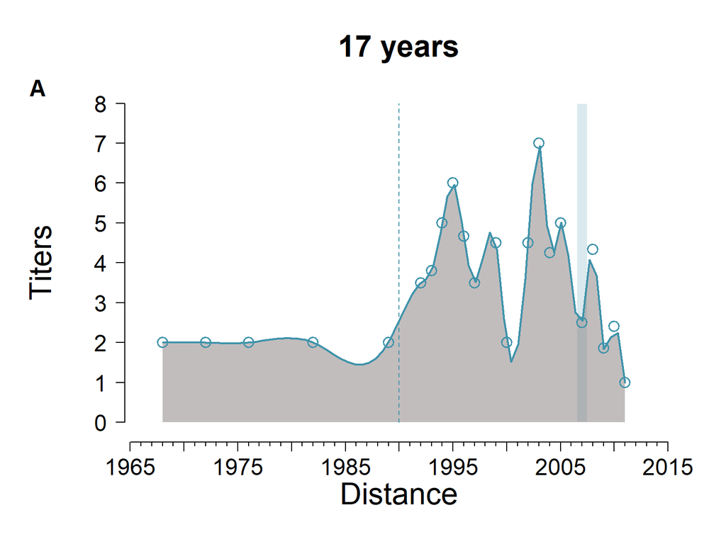

```r
# add the column indicating participants' age
transformed_df$age <- transformed_df$`Sample Year` - transformed_df$`Year of Birth`

ids <- c(19)

# The plotted profile's id is 19 and group is 2007
sapply(1:length(ids), function(i) {

  individualPlot(i = i,
                 ids = ids,
                 df = transformed_df,
                 part_col = "Subject Number",
                 weight_col = "isolation_year",
                 val_col = "titer",
                 group_col = "Sample Year",
                 groups = 2007,
                 age_col = "age",
                 birth_col = "Year of Birth",
                 sample_years = 2007,
                 mode = "mean",
                 var_trans = 0,
                 adjust = -2,
                 x.min = 1965,
                 x.max = 2015,
                 y.min = 0,
                 y.max = 8,
                 legends = "A")

})
```

You can also plot multiple individual profiles in different sample groups, if applicable.

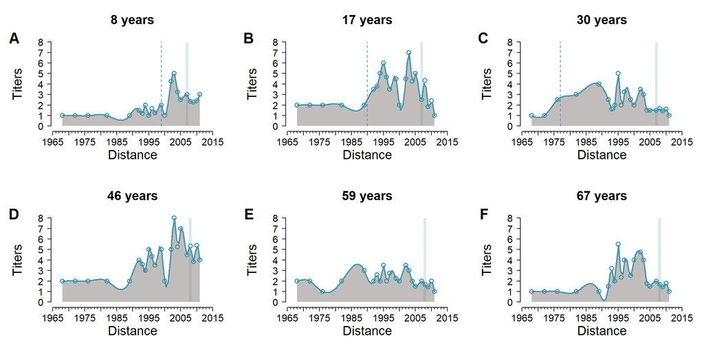

```r
ids <- c(48,19,36,2,23,46)

mat <- rbind(matrix(1:6,
                    nrow = 2, ncol = 3,
                    byrow = TRUE))

layout(mat,
       widths = rep(1.5, 3),
       heights = c(1.0, 1.0))

# The plotted profiles' (id, group) are (43, 2007), (19, 2007), (36, 2007), (2, 2008), (23, 2008), (46,2008).
sapply(1:length(ids), function(i) {

  individualPlot(i = i,
                 ids = ids,
                 df = transformed_df,
                 part_col = "Subject Number",
                 weight_col = "isolation_year",
                 val_col = "titer",
                 group_col = "Sample Year",
                 groups = c(rep(2007, 3), rep(2008,3)), # This determines the sample group of the profile.
                 age_col = "age",
                 birth_col = "Year of Birth",
                 sample_years = c(rep(2007, 3), rep(2008,3)),
                 mode = "mean",
                 var_trans = 0,
                 adjust = -2,
                 x.min = 1965,
                 x.max = 2015,
                 y.min = 0,
                 y.max = 8,
                 legends = LETTERS[1:6])

})
```

##### 3.1.3.2. Profile Comparison

Use the function `dualPlot()` to plot the comparison between a pair of profiles. The profiles in a pair can be from different participants and different sample groups. In other words, any two different profiles would be applicable.

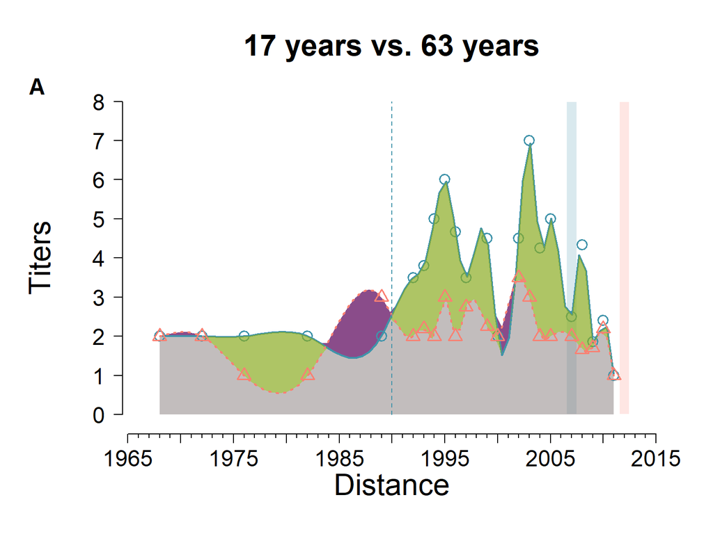

```r
ids.1 <- c(19)
ids.2 <- c(23)

# The comparison would be between the profile whose id is 19 and group is 2007, and the profile whose id is 23 and group is 2012.
sapply(1:length(ids.1), function(i) {

  dualPlot(i = i,
           ids.1 = ids.1,
           ids.2 = ids.2,
           df = transformed_df,
           part_col = "Subject Number",
           weight_col = "isolation_year",
           val_col = "titer",
           group_col = "Sample Year",
           groups.1 = 2007,
           groups.2 = 2012,
           age_col = "age",
           birth_col = "Year of Birth",
           sample_years.1 = 2007,
           sample_years.2 = 2012,
           mode = "mean",
           var_trans = 0,
           adjust = -2,
           x.min = 1965,
           x.max = 2015,
           y.min = 0,
           y.max = 8,
           legends = "A")

})
```

You can also plot comparisons between multiple pairs of profiles.

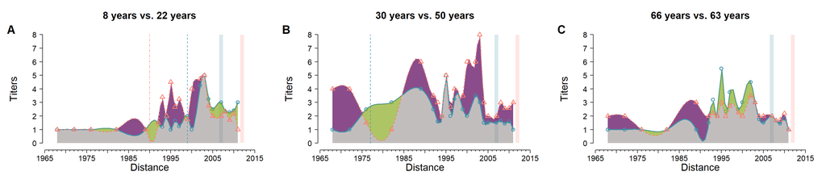

```r
ids.1 <- c(48,36,46) # Randomly chosen numbers
ids.2 <- c(19,2,23) # Randomly chosen numbers

mat <- rbind(matrix(1:3,
                    nrow = 1, ncol = 3,
                    byrow = TRUE))

layout(mat,
       widths = rep(1.5, 3),
       heights = c(1.0))

# [(id1, group1), (id2, group2)] states the comparison between the profile whose id is id1 and group is group1, and the profile whose id is id2 and group is group2.

# The following comparisons would be between three pairs of profiles: [(48, 2007), (19, 2012)], [(36, 2007), (2, 2012)], [(46, 2007), (23, 2012)].

sapply(1:length(ids.1), function(i) {

  dualPlot(i = i,
           ids.1 = ids.1,
           ids.2 = ids.2,
           df = transformed_df,
           part_col = "Subject Number",
           weight_col = "isolation_year",
           val_col = "titer",
           group_col = "Sample Year",
           groups.1 = rep(2007, 3), # This determines the sample group of the first participants in the comparison pairs.
           groups.2 = rep(2012, 3), # This determines the sample group of the second participants in the comparison pairs.
           age_col = "age",
           birth_col = "Year of Birth",
           sample_years.1 = rep(2007, 3),
           sample_years.2 = rep(2012, 3),
           mode = "mean",
           var_trans = 0,
           adjust = -2,
           x.min = 1965,
           x.max = 2015,
           y.min = 0,
           y.max = 8,
           legends = LETTERS[1:6])

})
```

##### 3.1.3.3. Conceptual Plot

Use the function `conceptualPlotAUC()`, `conceptualPlotWidth()`, `conceptualPlotATY()` to plot the conceptual plots of a profile, giving insights into the profile regarding AUC, Width, and ATY.

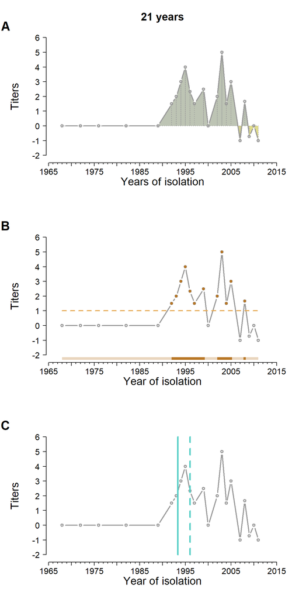

```r
ids <- c(19)

mat <- rbind(matrix(1:3,
                    nrow = 3, ncol = 1,
                    byrow = FALSE))

layout(mat,
       widths = 1.5,
       heights = c(1.0, 1.0, 1.0))

# The conceptual plots of the profile whose id is 19 and goup is 2011.
sapply(1:length(ids), function(i) {

  # auc
  conceptualPlotAUC(i = i,
                    ids = ids,
                    df = transformed_df,
                    part_col = "Subject Number",
                    weight_col = "isolation_year",
                    val_col = "titer",
                    group_col = "Sample Year",
                    groups = 2011,
                    age_col = "age",
                    var_trans = 0,
                    mode = "mean",
                    y.min = -2,
                    y.max = 6,
                    legends = LETTERS[1])

  # width 1:40
  conceptualPlotWidth(i = i,
                      ids = ids,
                      df = transformed_df,
                      part_col = "Subject Number",
                      weight_col = "isolation_year",
                      val_col = "titer",
                      group_col = "Sample Year",
                      groups = 2011,
                      var_trans = 0,
                      mode = "mean",
                      cutoff = 1,
                      y.min = -2,
                      y.max = 6,
                      legends = LETTERS[2])

  # aty
  conceptualPlotATY(i = i,
                    ids = ids,
                    df = transformed_df,
                    part_col = "Subject Number",
                    weight_col = "isolation_year",
                    val_col = "titer",
                    group_col = "Sample Year",
                    groups = 2011,
                    var_trans = 0,
                    mode = "mean",
                    y.min = -2,
                    y.max = 6,
                    legends = LETTERS[3])

})
```

You can plot conceptual plots of multiple profiles as well.

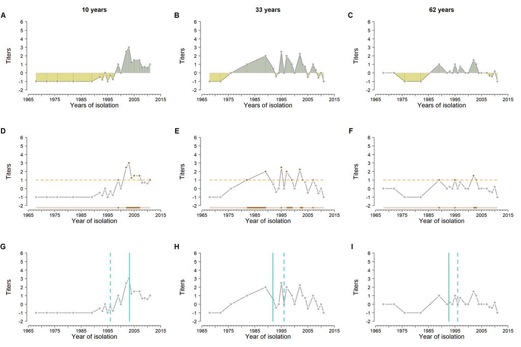

```r
ids <- c(48,36,23)

mat <- rbind(matrix(1:9,
                    nrow = 3, ncol = 3,
                    byrow = FALSE))

layout(mat,
       widths = rep(1.5, 3),
       heights = c(1.0, 1.0, 1.0))

# The conceptual plots of the profiles whose (id, group) are (48, 2009), (36, 2010), (23, 2011).
sapply(1:length(ids), function(i) {

  # auc
  conceptualPlotAUC(i = i,
                    ids = ids,
                    df = transformed_df,
                    part_col = "Subject Number",
                    weight_col = "isolation_year",
                    val_col = "titer",
                    group_col = "Sample Year",
                    groups = c(2009, 2010, 2011), # This determines the sample group of the profiles.
                    age_col = "age",
                    var_trans = 0,
                    mode = "mean",
                    y.min = -2,
                    y.max = 6,
                    legends = LETTERS[1:3])

  # width 1:40
  conceptualPlotWidth(i = i,
                      ids = ids,
                      df = transformed_df,
                      part_col = "Subject Number",
                      weight_col = "isolation_year",
                      val_col = "titer",
                      group_col = "Sample Year",
                      groups = c(2009, 2010, 2011),
                      var_trans = 0,
                      mode = "mean",
                      cutoff = 1,
                      y.min = -2,
                      y.max = 6,
                      legends = LETTERS[4:6])

  # aty
  conceptualPlotATY(i = i,
                    ids = ids,
                    df = transformed_df,
                    part_col = "Subject Number",
                    weight_col = "isolation_year",
                    val_col = "titer",
                    group_col = "Sample Year",
                    groups = c(2009, 2010, 2011),
                    var_trans = 0,
                    mode = "mean",
                    y.min = -2,
                    y.max = 6,
                    legends = LETTERS[7:9])

})
```